# Text Prediction Application

YeongWei  
April 17th, 2016

### What Is This About ?!

**It's tough to predict the future but not words!**

Applications derived from `word based statistical model` has helped improve mankind's quality of life.

For examples,

1. [**SwiftKey Keyboard**](https://swiftkey.com/en) predicts the next word (as user types) that makes compostion task on mobile a breeze!
2. [**Text-To-Speech Synthesize**](https://en.wikipedia.org/wiki/Speech_synthesis) assists in speech construction when challenged by disability and breaks down physical communication boundaries. (E.g. Stephen Hawking)

### How It Works ?

The `High Level Architecture` as below,

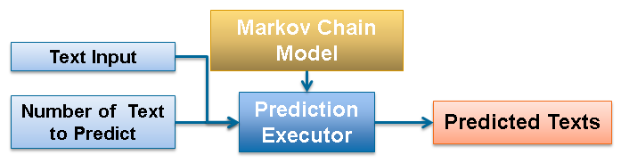

`Markov Chain Model` represents each word as transitional state with probability. An intuitive example, word “B” has 30% chance to transit to word “A”.

`Add-1 Smoothing` is applied to distribute probability mass to produce a less-biased prediction model.

### Too Easy !

Type some text and hit the `SUBMIT` button! Results come back less than seconds!

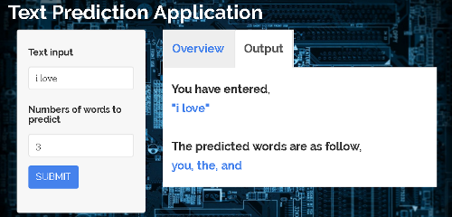

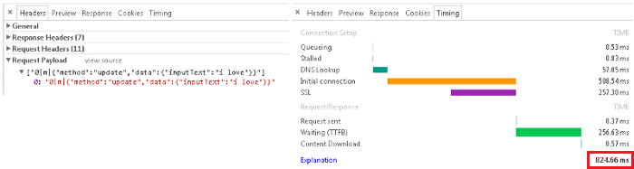

### What's Next ?

The prediction model is somewhat skewed. Possible improvements are,

1. Increase Corpus size and/or type.
2. Increase machine resources - create more complex model.
3. Increase Shiny io resources - host more complex text prediction application.

What are you waiting for ? Give it a try [here](https://yeongwei116.shinyapps.io/data-science-capstone/) or [here](https://yeongwei.shinyapps.io/data-science-capstone/)!

For more detailed information about the implementation, click [here](https://github.com/yeongwei/coursera-datascience-capstone).